# Obróbka danych

A. M. Machno

## Czemu dane powinny być czyste?

Wszystkie dane w trakcie tworzenia nie nadają się do analizy. Ich format nie pozwala na efektywne modelowanie. Czyste dane to dane przedstawione w odpowiednim formacie, nadający się do znaczącej analizy.

W czasach *Big Data* zagadnienia porządkowania danych do analizy oraz wykrywania nieprawidłowości jest coraz istotniejszy i bardziej skomplikowany. Wraz ze powiększaniem się zestawów danych, ilość potencjalnych kłopotów w formatowaniu danych i identyfikacji problemów jest coraz większa.

Czyszczenie danych składa się z trzech kroków:

1. Badanie danych surowych.
2. Uporządkowanie danych.
3. Przygotowanie danych do analizy.

## Badanie danych surowych (1)

1. Zrozumienie struktury danych.
   - wczytanie danych
   - `class()`, `dim()`, `names()`
   - `str()`, “dplyr::glimpse()”
   - `summary()`
2. Spojrzenie do danych.
3. Wizualizacja danych.

## Zrozumienie struktury danych (1)

```r
# wczytuję dane bmi.csv
bmi <- read.csv("data/bmi_clean.csv")
# Sprawdzamy klasę bmi
class(bmi)
```

```
## [1] "data.frame"
```

```r
# wymiar bmi
dim(bmi)
```

```
## [1] 199  30
```

```r
# nazwy kolumn bmi
names(bmi)
```

```
##  [1] "Country" "Y1980"   "Y1981"   "Y1982"   "Y1983"   "Y1984"   "Y1985"
##  [8] "Y1986"   "Y1987"   "Y1988"   "Y1989"   "Y1990"   "Y1991"   "Y1992"
## [15] "Y1993"   "Y1994"   "Y1995"   "Y1996"   "Y1997"   "Y1998"   "Y1999"
## [22] "Y2000"   "Y2001"   "Y2002"   "Y2003"   "Y2004"   "Y2005"   "Y2006"
## [29] "Y2007"   "Y2008"
```

## Zrozumienie struktury danych (2)

```r
str(bmi)
```

```
## 'data.frame':    199 obs. of  30 variables:
##  $ Country: Factor w/ 199 levels "Afghanistan",..: 1 2 3 4 5 6 7 8 9 10 ...
##  $ Y1980  : num  21.5 25.2 22.3 25.7 20.9 ...
##  $ Y1981  : num  21.5 25.2 22.3 25.7 20.9 ...
##  $ Y1982  : num  21.5 25.3 22.4 25.7 20.9 ...
##  $ Y1983  : num  21.4 25.3 22.5 25.8 20.9 ...
##  $ Y1984  : num  21.4 25.3 22.6 25.8 20.9 ...
##  $ Y1985  : num  21.4 25.3 22.7 25.9 20.9 ...
##  $ Y1986  : num  21.4 25.3 22.8 25.9 21 ...
##  $ Y1987  : num  21.4 25.3 22.8 25.9 21 ...
##  $ Y1988  : num  21.3 25.3 22.9 26 21 ...
##  $ Y1989  : num  21.3 25.3 23 26 21.1 ...
##  $ Y1990  : num  21.2 25.3 23 26.1 21.1 ...
##  $ Y1991  : num  21.2 25.3 23.1 26.2 21.1 ...
##  $ Y1992  : num  21.1 25.2 23.2 26.2 21.1 ...
```

[output cut: 16 more lines]

## Zrozumienie struktury danych (3)

```r
summary(bmi)
```

```
##                 Country        Y1980           Y1981           Y1982
##  Afghanistan        :  1   Min.   :19.01   Min.   :19.04   Min.   :19.07
##  Albania            :  1   1st Qu.:21.27   1st Qu.:21.31   1st Qu.:21.36
##  Algeria            :  1   Median :23.31   Median :23.39   Median :23.46
##  Andorra            :  1   Mean   :23.15   Mean   :23.21   Mean   :23.26
##  Angola             :  1   3rd Qu.:24.82   3rd Qu.:24.89   3rd Qu.:24.94
##  Antigua and Barbuda:  1   Max.   :28.12   Max.   :28.36   Max.   :28.58
##  (Other)            :193
##      Y1983           Y1984           Y1985           Y1986
##  Min.   :19.10   Min.   :19.13   Min.   :19.16   Min.   :19.20
##  1st Qu.:21.42   1st Qu.:21.45   1st Qu.:21.47   1st Qu.:21.49
##  Median :23.57   Median :23.64   Median :23.73   Median :23.82
##  Mean   :23.32   Mean   :23.37   Mean   :23.42   Mean   :23.48
##  3rd Qu.:25.02   3rd Qu.:25.06   3rd Qu.:25.11   3rd Qu.:25.20
##  Max.   :28.82   Max.   :29.05   Max.   :29.28   Max.   :29.52
##
##      Y1987           Y1988           Y1989           Y1990
##  Min.   :19.23   Min.   :19.27   Min.   :19.31   Min.   :19.35
##  1st Qu.:21.50   1st Qu.:21.52   1st Qu.:21.55   1st Qu.:21.57
##  Median :23.87   Median :23.93   Median :24.03   Median :24.14
##  Mean   :23.53   Mean   :23.59   Mean   :23.65   Mean   :23.71
##  3rd Qu.:25.27   3rd Qu.:25.34   3rd Qu.:25.37   3rd Qu.:25.39
##  Max.   :29.75   Max.   :29.98   Max.   :30.20   Max.   :30.42
##
##      Y1991           Y1992           Y1993           Y1994
##  Min.   :19.40   Min.   :19.45   Min.   :19.51   Min.   :19.59
##  1st Qu.:21.60   1st Qu.:21.65   1st Qu.:21.74   1st Qu.:21.76
##  Median :24.20   Median :24.19   Median :24.27   Median :24.36
##  Mean   :23.76   Mean   :23.82   Mean   :23.88   Mean   :23.94
##  3rd Qu.:25.42   3rd Qu.:25.48   3rd Qu.:25.54   3rd Qu.:25.62
##  Max.   :30.64   Max.   :30.85   Max.   :31.04   Max.   :31.23
##
##      Y1995           Y1996           Y1997           Y1998
##  Min.   :19.67   Min.   :19.71   Min.   :19.74   Min.   :19.77
##  1st Qu.:21.83   1st Qu.:21.89   1st Qu.:21.94   1st Qu.:22.00
##  Median :24.41   Median :24.42   Median :24.50   Median :24.49
##  Mean   :24.00   Mean   :24.07   Mean   :24.14   Mean   :24.21
##  3rd Qu.:25.70   3rd Qu.:25.78   3rd Qu.:25.85   3rd Qu.:25.94
##  Max.   :31.41   Max.   :31.59   Max.   :31.77   Max.   :31.95
##
```

[output cut: 9 more lines]

```
##  Min.   :19.81   Min.   :19.79   Min.   :19.79   Min.   :19.80
##  1st Qu.:22.37   1st Qu.:22.45   1st Qu.:22.54   1st Qu.:22.63
##  Median :24.89   Median :25.00   Median :25.11   Median :25.24
##  Mean   :24.61   Mean   :24.70   Mean   :24.79   Mean   :24.89
##  3rd Qu.:26.38   3rd Qu.:26.47   3rd Qu.:26.53   3rd Qu.:26.59
##  Max.   :32.90   Max.   :33.10   Max.   :33.30   Max.   :33.49
##
##      Y2007           Y2008
##  Min.   :19.83   Min.   :19.87
##  1st Qu.:22.73   1st Qu.:22.83
##  Median :25.36   Median :25.50
##  Mean   :24.99   Mean   :25.10
##  3rd Qu.:26.66   3rd Qu.:26.82
##  Max.   :33.69   Max.   :33.90
##
```

## Spojrzenie w dane

Bezpośrednie spojrzenie w elementy danych możemy wykonać przez:

- `head()`: wyświelta domyślnie pierwsze 6 elementów obiektu, liczbę tę można modyfikować argumentem opcjonalnym `n`.
- `tail()`: analogicznie wyświetla ostanie elelemnty obiektu. W przypadku ramki dnaych, wyświetla ostatnie wiersze.
- `print()`, `View()`: pozwala wyświetlić całość danych. Użyteczne jedynie przy stosunkowo małych zbiorach danych. **Uwaga**: przed wyświelteniem danych należy zawsze sprawdzić przynajmniej wymiar danych.

Aby poznać strukturę konkretnych zmiennych w zestawie danych można użyć bardzo prostych funkcji graficznych:

- `hist()`: wyświetla histogram zmiennej liczbowej.
- `plot()`: produkuje wykres punktowy, umożliwiająć zobrazowanie zależności dwuwymiarowej.

## Patrzenie w dane (1)

```r
# Wyświetlenie danych
print(bmi)
```

```
##                              Country    Y1980    Y1981    Y1982    Y1983
## 1                        Afghanistan 21.48678 21.46552 21.45145 21.43822
## 2                            Albania 25.22533 25.23981 25.25636 25.27176
## 3                            Algeria 22.25703 22.34745 22.43647 22.52105
## 4                            Andorra 25.66652 25.70868 25.74681 25.78250
## 5                             Angola 20.94876 20.94371 20.93754 20.93187
## 6                Antigua and Barbuda 23.31424 23.39054 23.45883 23.53735
## 7                          Argentina 25.37913 25.44951 25.50242 25.55644
## 8                            Armenia 23.82469 23.86401 23.91023 23.95649
## 9                          Australia 24.92729 25.00216 25.07660 25.14938
## 10                           Austria 24.84097 24.88110 24.93482 24.98118
## 11                        Azerbaijan 24.49375 24.52584 24.56064 24.60150
## 12                           Bahamas 24.21064 24.30814 24.42750 24.54415
## 13                           Bahrain 23.97588 24.09045 24.20617 24.32335
## 14                        Bangladesh 20.51918 20.47766 20.43741 20.40075
```

[output cut: 985 more lines]

## Patrzenie w dane (2)

```r
# Pierwsze 3 wiersze
head(bmi, 3)
```

```
##       Country    Y1980    Y1981    Y1982    Y1983    Y1984    Y1985
## 1 Afghanistan 21.48678 21.46552 21.45145 21.43822 21.42734 21.41222
## 2     Albania 25.22533 25.23981 25.25636 25.27176 25.27901 25.28669
## 3     Algeria 22.25703 22.34745 22.43647 22.52105 22.60633 22.69501
##      Y1986    Y1987    Y1988    Y1989    Y1990    Y1991    Y1992    Y1993
## 1 21.40132 21.37679 21.34018 21.29845 21.24818 21.20269 21.14238 21.06376
## 2 25.29451 25.30217 25.30450 25.31944 25.32357 25.28452 25.23077 25.21192
## 3 22.76979 22.84096 22.90644 22.97931 23.04600 23.11333 23.18776 23.25764
##      Y1994    Y1995    Y1996    Y1997    Y1998    Y1999    Y2000    Y2001
## 1 20.97987 20.91132 20.85155 20.81307 20.78591 20.75469 20.69521 20.62643
## 2 25.22115 25.25874 25.31097 25.33988 25.39116 25.46555 25.55835 25.66701
## 3 23.32273 23.39526 23.46811 23.54160 23.61592 23.69486 23.77659 23.86256
##      Y2002    Y2003    Y2004    Y2005    Y2006    Y2007    Y2008
## 1 20.59848 20.58706 20.57759 20.58084 20.58749 20.60246 20.62058
## 2 25.77167 25.87274 25.98136 26.08939 26.20867 26.32753 26.44657
## 3 23.95294 24.05243 24.15957 24.27001 24.38270 24.48846 24.59620
```

## Patrzenie w dane (3)

```r
# Ostatnie 2 wiersze
tail(bmi, 2)
```

```
##      Country    Y1980    Y1981    Y1982    Y1983    Y1984    Y1985
## 198   Zambia 19.66295 19.69512 19.72538 19.75420 19.78070 19.80335
## 199 Zimbabwe 21.46989 21.48867 21.50738 21.52936 21.53383 21.54341
##        Y1986    Y1987    Y1988    Y1989    Y1990    Y1991    Y1992
## 198 19.82396 19.85065 19.88320 19.92451 19.96680 20.00746 20.04096
## 199 21.54859 21.54590 21.55396 21.56903 21.58005 21.59694 21.59010
##        Y1993    Y1994    Y1995    Y1996    Y1997    Y1998    Y1999
## 198 20.07781 20.09502 20.09977 20.11009 20.12375 20.13349 20.15094
## 199 21.58547 21.59029 21.58986 21.60362 21.62721 21.65496 21.68873
##        Y2000    Y2001    Y2002    Y2003    Y2004    Y2005    Y2006
## 198 20.17261 20.20266 20.24298 20.29474 20.35966 20.43398 20.51422
## 199 21.72652 21.76514 21.79645 21.82499 21.85806 21.89495 21.93371
##        Y2007    Y2008
## 198 20.59770 20.68321
## 199 21.97405 22.02660
```

## Histogram BMI w 2003 roku

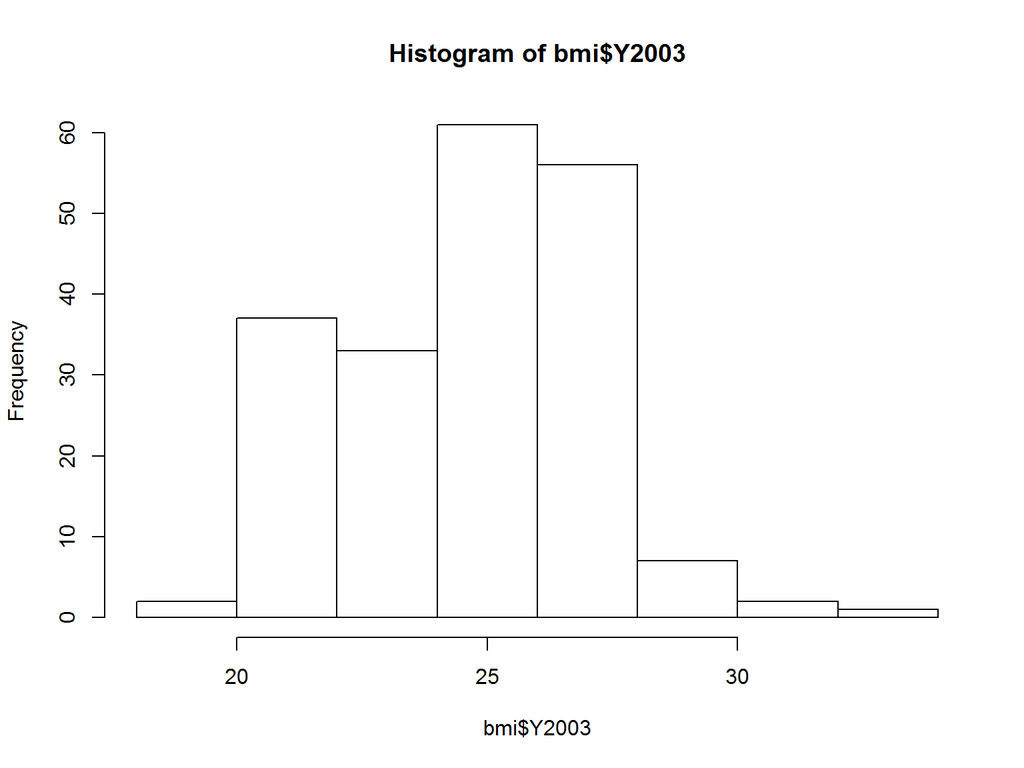

```r
hist(bmi$Y2003)
```

## Wykres zależności BMI w 1990 i 2005

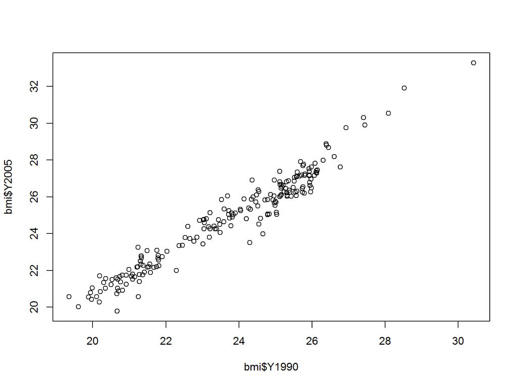

```r
plot(bmi$Y1990, bmi$Y2005)
```

## Cechy czystych danych

- Każdy wiersz jest obserwacją.
- Każda kolumna jest zmienną (atrybut). Każdy z elementów zmiennej jest wartością tej zmiennej dla obserwacji z danego wiersza.
- Obserwacje powinny być jednego rodzaju. W jednym zestawie danych powinny znajdować się obserwacje o tych samych charakterystykach (zmiennych).
- Brak błędnych danych i zrozumiały powód występowania wartości brakujących.

## ćwiczenia

1. Zbadać dane `bmi` dostępne pod [linkiem](https://raw.githubusercontent.com/amachno/R_course_UJ_ed1/master/bmi_clean.csv). Określić, jakie elementy tych danych nie spełniają założeń czystych danych.

## Dane szerokie a dane długie

Często te same informacje możemy przedstawić w różnych formatach. Częstym dylematem jest czy niektóre atrybuty nie powinny być wartościami zmiennej określającej typ wartości.

```r
# dane szerokie
wide_df
```

```
##   col A B C
## 1   X 1 2 3
## 2   Y 2 4 6
```

```r
#wczytujemy pakiet tidyr
```

## Zamiana nazw kolumn na wartości

```r
library(tidyr)
# uzywamy funkcji gather() do zebrania kolumn
# w wartości wierszy
gather(wide_df, key, value, -col)
```

```
##   col key value
## 1   X   A     1
## 2   Y   A     2
## 3   X   B     2
## 4   Y   B     4
## 5   X   C     3
## 6   Y   C     6
```

## Argumenty funkcji tidyr::gather()

`gather(data, key, value, ...)`

- `data`: ramka danych.
- `key`: nowa nazwa nowej kolumny, w której przechowywane będą nazwy zbieranych atrybutów.
- `value`: nowa nazwa kolumny, w której przechowywane będą wartości zbieranych atrybutów.
- `...`: nazwy kolumn które należy lub nie należy zebrać.

## Rozwinięcie atrybutu

Operacją odwrotną do zebrania argumentów jest rozwinięcie argumentu. Działanie takie zamienia dane długie na szerokie. Funkcją pakietu `tidyr` rozwijające kolumnę to `spred()`.

`spread(data, key, value)`

- `data`: ramka danych.
- `key`: nazwa kolumny, w której przechowywane są nazwy atrybutów, które chcemy rozwinąć.
- `value`: nazwa kolumny, w której przechowywane są wartości atrybutów, które stanowwić będą wartości w nowych kolumnach.

Jako wynik otrzymujemy ramkę danych, w której zamiast kolumn `key` oraz `value` występują kolumny o nazwach wartości starej zmiennej `key` i odpowiednich wartościach ze starej kolumny `value`.

## Rozwinięcie atrybutu- przykład

Długie dane stworzone porzyżej zostały zapisane w ramce `long_df`.

```r
# odtwarzamy wide_df z long_df przy pomocy spread()
spread(long_df, key, value)
```

```
##   col A B C
## 1   X 1 2 3
## 2   Y 2 4 6
```

## Rozdzielenie kolumny

Często w danych możemy otrzymać w jednej kolumnie kilka zmiennych. W innych przypadkach takie zmienne jak data możemy mieć potrzebę rozdzielić na nowe zmienne rok i miesiąc. Funckją pakietu `tidyr` rozdzielającą kolumnę jest `separate()`.

`separate(data, col, into)`

- `data`: ramka danych.
- `col`: nazwa kolumny, którą chcemy podzielić.
- `into`: wektor nazw kolumn w nowej ramce danych powstałych z części kolumny `col`.

Poza obowiązkowymi argumentami objaśnionymi powyżej użytecznym argumentem jest `sep` określający znak, którym części obserwacji są rodzielone. Argumentu teo należy użyć jeśli mogą istnieć inne znaki specjalne w w wartościach kolumny `col`. Ponadto argument `remove` określa czy kolumna `col` powinna występować w nowej ramce danych.

## Dane z kolumną do rozdzielenia

```r
# dane dotyczące 3 kuracji 2 pacjentów
treatment
```

```
##   patient treatment    date response
## 1       X         a 2016-12        2
## 2       Y         a 2016-12        6
## 3       X         b 2015-11        3
## 4       Y         b 2015-11        4
## 5       X         c 2015-01        1
## 6       Y         c 2015-01        5
```

## Rozdzielenie kolumny z datą

```r
separate(treatment, date, c("year", "month"))
```

```
##   patient treatment year month response
## 1       X         a 2016    12        2
## 2       Y         a 2016    12        6
## 3       X         b 2015    11        3
## 4       Y         b 2015    11        4
## 5       X         c 2015    01        1
## 6       Y         c 2015    01        5
```

## Łączenie kolumn

Funkcją odwrotną do `separate()` jest `unite()`, która łączy wartości wskazanych kolumn w jeden napis.

`unite(data, col, ...)`

- `data`: ramka danych.
- `col`: nazwa nowej kolumny, w której wstawimy sklejone wartości.
- `...`: nazwy kolumn które należy skleić. Kolejność wpisania kolumn ma znaczenie i w tej kolejności będą sklejone wartości.

Analogicznie do `separate()`, funkcja `unite()` posiada opcjonalne argumenty `remove` oraz `sep`, którego domyślna wartość to podkreślenie `_`.

## Łączenie kolumn: przykład

Ĺączymy spowrotem rok i miesiąc rozdzielone powyżej. Otrzymany wynik zapisany jest w ramce `treatment_sep`.

```r
unite(treatment_sep, new_date, c(year, month))
```

```
##   patient treatment new_date response
## 1       X         a  2016_12        2
## 2       Y         a  2016_12        6
## 3       X         b  2015_11        3
## 4       Y         b  2015_11        4
## 5       X         c  2015_01        1
## 6       Y         c  2015_01        5
```

## Typowe objawy brudnych danych

- Nazwy kolumn będące wartościami, a nie nazwą zmiennej.
- Zmienne bądące przechowywane w wierszach oraz kolumnach.
- Kilka zmiennych przechowywanych w jednej kolumnie.
- Obiekty tej samej klasy przechowywane w różnych tablicach.
- Obiekty różnych klas przechowywane w jednej tablicy

## Nazwy kolumn będące wartościami

```r
people
```

```
##    name age brown blue other height
## 1  Ania  18     0    0     1    170
## 2 Jacek  40     1    0     0    181
## 3 Tomek  41     0    1     0    179
## 4 Gosia  19     0    0     1    167
```

## Nazwy zmiennych w wierszach

```r
people
```

```
##    name measurment value
## 1  Ania     n_dogs     0
## 2  Ania     n_cats     1
## 3  Ania    n_birds     1
## 4 Jacek     n_dogs     2
## 5 Jacek     n_cats     0
## 6 Jacek    n_birds     2
```

## Kilka zmiennych przechowywanych w jednej kolumnie

```r
people
```

```
##    name sex_age eye_color height
## 1  Ania    F.18     other    170
## 2 Jacek    M.40     brown    181
## 3 Tomek    M.41      blue    179
## 4 Gosia    F.19     other    167
```

## Obiekty różnych klas

```r
people
```

```
##    name age height   petname pet_type pet_height
## 1  Ania  18    170    Square      dog         70
## 2  Ania  18    170  Triangle      cat         35
## 3  Ania  18    170 Rectangle     bird         10
## 4 Jacek  40    181  Heptagon      cat         40
## 5 Jacek  40    181    Circle      dog         35
```

## ćwiczenia

1. Dla danych `bmi` dostępnych pod [linkiem](https://raw.githubusercontent.com/amachno/R_course_UJ_ed1/master/bmi_clean.csv) stowrzyć wersję długą z rokiem będącym dodatkowym atrybutem.
2. Korzystając z danych otrzymanych w 1., odtworzyć oryginalna szeroką wersję danych.
3. Dla danych o uczniach dostępnych pod [linkiem](https://raw.githubusercontent.com/amachno/R_course_UJ_ed1/master/students_with_dates.csv) rozdzielić kolumnę `grade` na trzy osobne oceny będące liczbami naturalnymi.

## Po co manipulować dane?

Manipulacja danymi (*data manipulation*) jest elementem procesu przygotowania danych do analizy. Możliwymi operacjami modyfikującymi dane, które bywaja przydatne w procesie przygotowania danych, zobrazowania danych lub analizy statystycznej są:

- Usunięcie niepotrzebnych zmiennych lub obserwacji.
- Uporządkowanie kolejności zmiennych lub obserwacji.
- Stworzenie nowej zmiennej powstałej przez przekształcenie innych zmiennych, np. współczynnik będący ilorazem dwóch innych zmiennych.
- Obliczenie statystyk opisowych zmiennych, takich jak średnia czy kwantyle.
- Połączenie dwóch tabel lub zmapowanie wartości jednej z tabel do drugiej.

## Pakiet *dplyr*

Manipulacja danymi jest bardzo obszernym zagadnieniem, składać się na nią może bardzo wiele operacji. Operacje te można wykonać przy pomocy podstawowych funkjcji i metod R. Często jednak użycie podstawowych metod jest nieintuicyjne, a tworzone kody sa nieczytelne.

Pakier `dplyr` został stworzony specjalnie na potrzeby manipulacji danymi. Jego podstawowymi zaletami są:

- Spójność funkcji, klas, nazw atrybutów itp.
- Szybkość działania. Wiele potencjalnie obciążających funkcji napisanych jest w C++.
- Intuicyjne użycie i funkcjonalność umozliwiająca tworzenie przejrzystych kodów.
- Możliwość korzystania zdalnego na bazach danych. Funkcje pakietu są przetłumaczone na język SQL i ich wywołanie na elementach bazy danych skutkuje przekazania odpowiedniego zapytania SQL.